# Predicting WAR in Baseball using KNN

Author

Milo Coolman

# Introduction

I am using the ‘baseballr’ package to scrape baseball statistics. In particular, I am looking at batting statistics from the 2021, 2022, 2023, and 2024 seasons, focusing on players with over 100 Plate Appearances. This data is scraped from the website fangraphs.com which is a website that contains the some of the most comprehensive baseball statistics that exist. The dataset that I have created has a total of 1848 players across 4 seasons. It contains stats such as Games played, At bats, Hits, Singles, Doubles, HRs, AVG, OPS, SLG, OPS, and many more.

The goal of this project is to use a knn model to predict WAR (Wins Above Replacement) as accurately as possible. WAR is a stat, that put as generally as possible, determines how many extra wins a team would get by playing this player as opposed to the average replacement. The highest single season WAR since 1980 was by Dwight Gooden of the New York Mets in 1985. Dwight had a WAR of 13.3, which means that the Mets won an extra 13.3 games by having Dwight Gooden than they would have with an average replacement playing instead.

```r
library(baseballr)
library(tidyverse)
batting_stats_2024 <- fg_bat_leaders(startseason = "2024", endseason = "2024", sortstat = "WAR") |>
  relocate(WAR) |>
  filter(PA >= 100)
batting_stats_2023 <- fg_bat_leaders(startseason = "2023", endseason = "2023", sortstat = "WAR") |>
  relocate(WAR) |>
  filter(PA >= 100)
batting_stats_2022 <- fg_bat_leaders(startseason = "2022", endseason = "2022", sortstat = "WAR") |>
  relocate(WAR) |>
  filter(PA >= 100)
batting_stats_2021 <- fg_bat_leaders(startseason = "2021", endseason = "2021", sortstat = "WAR") |>
  relocate(WAR) |>
  filter(PA >= 100)

batting_stats_df <- bind_rows(batting_stats_2021, batting_stats_2022, batting_stats_2023, batting_stats_2024) |>
  arrange(desc(WAR)) |> select("WAR", "PlayerName", "Age", "G", "AB",
                               "PA", "H", "1B", "2B", "3B", "HR", "R", "RBI",
                               "BB", "IBB", "SO", "HBP", "SB", "CS", "AVG", "SF",
                               "SH", "IFH", "BB_pct", "K_pct", "BB_K", "OBP",
                               "SLG", "OPS", "wRC", "Batting", "Defense",
                               "Offense", "BaseRunning", "Clutch")
batting_stats_df

scale_vec <- c("Age", "G", "AB", "PA", "H", "1B", "2B", "3B", "HR", "R", "RBI",
               "BB", "IBB", "SO", "HBP", "SB", "CS", "AVG", "SF", "SH", "IFH",
               "BB_pct", "K_pct", "BB_K", "OBP", "SLG", "OPS", "wRC", "Batting",
               "Defense", "Offense", "BaseRunning", "Clutch")

batting_stats_scaled <- batting_stats_df |> mutate(across(scale_vec, ~ (.x - min(.x)) / (max(.x) - min(.x))))

set.seed(07012003)
batting_train <- batting_stats_scaled |> slice_sample(n = 1200)
batting_test <- anti_join(batting_stats_scaled, batting_train)
```

# Data Exploration

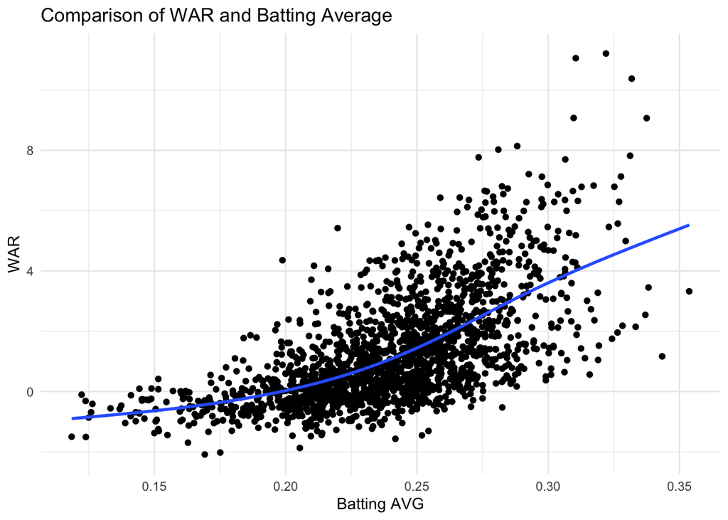

```r
ggplot(data = batting_stats_df, aes(x = AVG, y = WAR)) +
  geom_point() +
  geom_smooth(se = FALSE) +
  labs(title = "Comparison of WAR and Batting Average",
         x = "Batting AVG") +
  theme_minimal()
```

This graph shows a plot comparing WAR and Batting Average. Through this, we can see that there is some correlation between these two statistics. As Batting Average increases, WAR tends to increase as well.

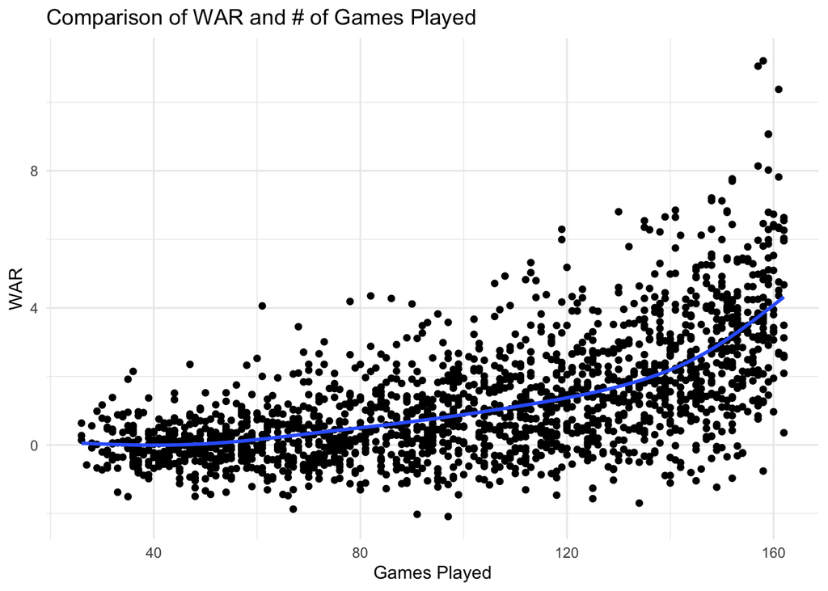

```r
ggplot(data = batting_stats_df, aes(x = G, y = WAR)) +
  geom_point() +
  geom_smooth(se = FALSE) +
  labs(title = "Comparison of WAR and # of Games Played",
         x = "Games Played") +
  theme_minimal()
```

This graph shows a plot comparing WAR and the Number of Games Played in a season. Through this, we can see that there seems to be a correlation between these two statistics, however this may not tell us as much as it seems. For starters, WAR is a cumulative statistic, so if two players had identical stats, the one who had played more games would be the one with a higher WAR. On top of that, players with better WAR, are better players, and as such would play in more games than say, a player with a poor WAR.

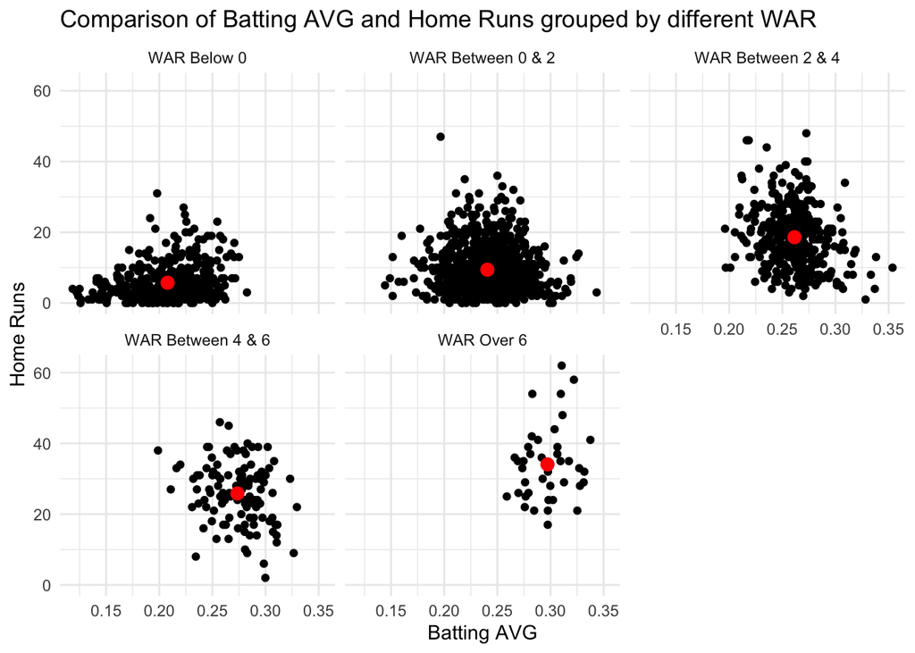

```r
ggplot(data = exploration_1, aes(x = AVG, y = HR)) +
  geom_point() +
  geom_point(data = exploration_1.1, aes(x = mean_AVG, y = mean_HR),
             colour = "red", size = 3) +
  facet_wrap(~ WAR_Cat) +
  theme_minimal() +
  labs(title = "Comparison of Batting AVG and Home Runs grouped by different WAR",
       x = "Batting AVG",
       y = "Home Runs")
```

This graph shows players with different WAR, grouped into 5 groups of WAR, and how their Batting Average compares to the amount of Home Runs that they hit. The red dot in each plot shows where the average player in each of these WAR categories lands in this comparison. From this we can see that as players get better (higher WAR), they tend to have both a higher batting average, and hit more home runs.

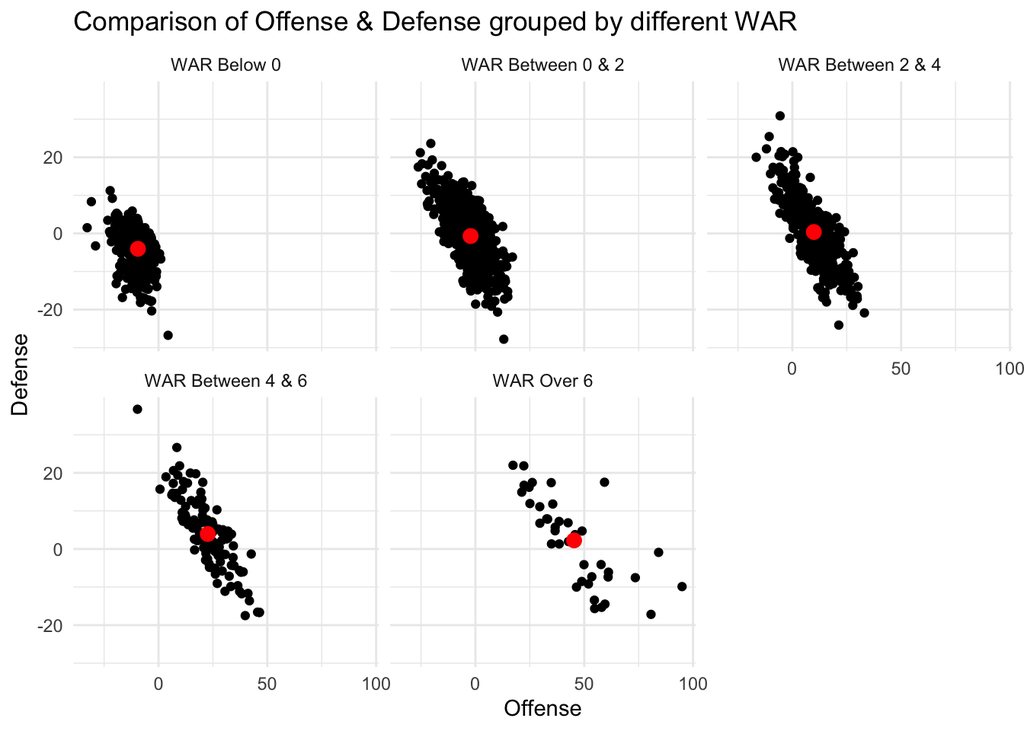

```r
ggplot(data = exploration_1, aes(x = Offense, y = Defense)) +
  geom_point() +
  geom_point(data = exploration_1.2, aes(x = mean_O, y = mean_D),
             colour = "red", size = 3) +
  facet_wrap(~ WAR_Cat) +
  theme_minimal() +
  labs(title = "Comparison of Offense & Defense grouped by different WAR")
```

This graph also shows players with different WAR, grouped into 5 groups of WAR, and how their Defense and Offense compare. Throughout all 5 groups, we see that the players who are better at Defense are worse at Offense. This makes sense, because if they were good at both, they would likely have a higher WAR and would therefore be in a different one of the 5 categories. As we look at the groups with higher and higher WAR, we see that the players tend to get better at both Offense and Defense, with the only caveat being that the average defense seems to get worse from the group of players with WAR between 4 and 6 to the group of players with WAR greater than 6.

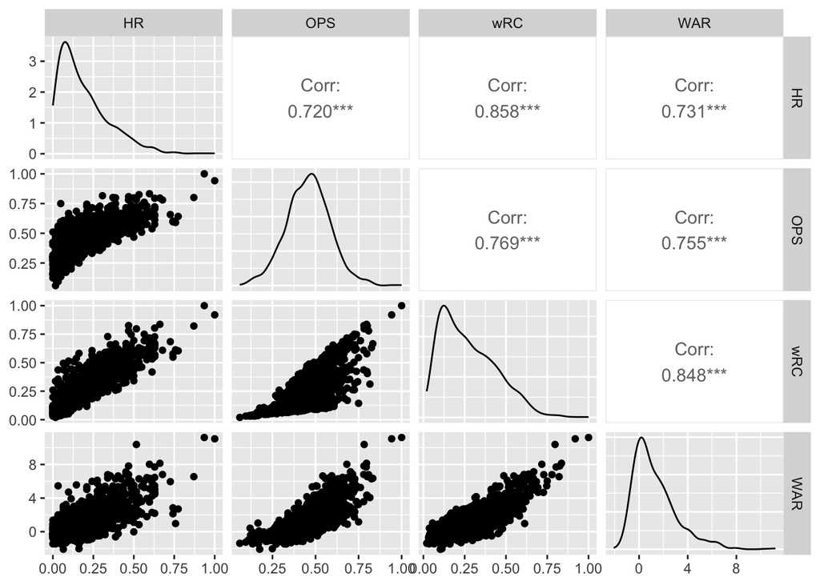

```r
library(GGally)
ggpairs(data = batting_train, columns = c(11, 29, 30, 1))
```

This plot shows how each of the 3 of the columns in the dataset that I will use for the knn analysis correlate to the WAR stat. Each of the variables have a fairly strong correlation with WAR. As each of these stats increase, the players WAR does as well.

# KNN Analysis

```r
library(class)
library(Metrics)
train_cat <- batting_train$WAR
test_cat <- batting_test$WAR


batting_train_small <- batting_train |> select(G, H, HR, OPS, Offense, Defense,
                                               Batting, wRC)

batting_test_small <- batting_test |> select(G, H, HR, OPS, Offense, Defense,
                                             Batting, wRC)


get_mae <- function(k_val) {
  knn_mod <- knn(train = batting_train_small, test = batting_test_small,
               cl = train_cat, k = k_val)

  knn_mod_double <- knn_mod |> as.character() |> as.double()

  mae(test_cat, knn_mod_double)
}

k_vec <- 1:30
mae_list <- map(k_vec, get_mae)
mae_vec <- mae_list |> unlist()
mae_df <- tibble(k_vec, mae_vec)
mae_df |> filter(mae_vec == min(mae_vec))
```

```
# A tibble: 1 × 2
  k_vec mae_vec
  <int>   <dbl>
1     1   0.351
```

For my knn model I used the following 8 predictors: G (# of Games Played), H (# of Hits), HR (# of Home Runs), OPS (On-Base Plus Slugging), Offense, Defense, Batting, and wRC (Weighted Runs Created). My model predicted WAR with a mean absolute error of 0.351. This error is roughly the difference between Juan Soto’s age 25 season and Fransisco Lindor’s age 30 season. A comparison between some of the more important and easily understandable statistics in each of their seasons is below:

```
# A tibble: 2 × 10
    WAR PlayerName           G   AVG   OBP   SLG    HR   RBI Offense Defense
  <dbl> <chr>            <int> <dbl> <dbl> <dbl> <int> <int>   <dbl>   <dbl>
1  8.14 Juan Soto          157 0.288 0.419 0.569    41   109    61.1   -6.09
2  7.77 Francisco Lindor   152 0.274 0.344 0.5      33    91    34.8   17.4
```

# Conclusion

I am quite content with how this project went. I was able to find a package in r that could potentially have future use cases for me if I go into sports analytics which is a field I would absolutely be interested in, and I was able to learn more about one of the most important statistics in Baseball, which happens to be one of my favorite sports. I was able to relatively accurately predict a players WAR. One thing that I would like to explore further is some of the functions within the baseballr package. One in particular is able to scrape data on players salary, but unfortunately I had some difficulties getting it to work. If I were to do another project, it would be to attempt to predict player salaries, with a potential use of determining how much money certain players going into free agency could expect to get, or another potential use for teams to figure out how much they should be willing to pay certain players.